# Swiftkey MIlestone Report

Nimish Sanghi

11/26/2016

## Introduction

The purpose of this report is to:

1. Demonstrate that data was downloaded successfully loaded it in R.
2. Create a basic report of summary statistics about the data sets.
3. Report any interesting findings
4. Get feedback on the plans for creating a prediction algorithm and Shiny app.

## Data Loading and Sampling

We will start with loading the data in R, followed by sampling to extract a representative set and then saving the sampled data back for future. We will also load all the required libraries. The data form three sources - blogs, news and twitter will be sampled and merged into a single file and saved back to disk with a name “samples.txt”.

- Loading the Libraries

```r
library(tm)
library(SnowballC)
library(ggplot2)
library(rJava)
.jinit(parameters="-Xmx128g")
library(RWeka)
```

- loading each of the three files and sampling a subset. The seed is set to 1310 to ensure reproducible.

```r
#read ramdom samples from blogs text file
setwd("~/Coursera/DataScience/data-science-project/finalProject")
con <- file("./final/en_US/en_US.blogs.txt","r")
blogs <- readLines(con, skipNul = TRUE)
blog_count <- length(blogs)
set.seed(1310)
blogs <- blogs[sample(length(blogs),0.01*length(blogs))]
close(con)

#read random samples from news text file
con <- file("./final/en_US/en_US.news.txt","r")
news <- readLines(con, skipNul = TRUE)
news_count <- length(news)
set.seed(1310)
news <- news[sample(length(news),0.01*length(news))]
close(con)

#read random samples from twitter text file
con <- file("./final/en_US/en_US.twitter.txt","r")
tweets <- readLines(con, skipNul = TRUE)
tweet_count <- length(tweets)
set.seed(1310)
tweets <- tweets[sample(length(tweets),0.01*length(tweets))]
close(con)


#combine the samples into a single file and write it back on disk
docs <- c(blogs, news, tweets)
sample_length <- length(docs)
con <- file("samples.txt")
writeLines(docs, con)
close(con)

#clean workspace
rm(tweets, docs, blogs, news)
```

The three files in total have **899288** blog items, **1010242** news items and **2360148** tweets. Out of this, I sampled a total of **42695** items for the following analysis.

## Sample Data preprocessing

These steps will make sample corpus ready for finding summary statistics of the word distribution.

```r
#read sample docs for text processing
setwd("~/Coursera/DataScience/data-science-project/finalProject")
con <- file("samples.txt","r")
docs <- VCorpus(VectorSource(readLines(con, skipNul = TRUE)))
close(con)


# pre processing
docs <- tm_map(docs, removePunctuation)
docs <- tm_map(docs, removeNumbers)
docs <- tm_map(docs, tolower)
docs <- tm_map(docs, removeWords, stopwords("english"))

# remove profanity words as found in the url
# https://raw.githubusercontent.com/LDNOOBW/List-of-Dirty-Naughty-Obscene-and-Otherwise-Bad-Words/master/en
profanityWords <- readLines("https://raw.githubusercontent.com/LDNOOBW/List-of-Dirty-Naughty-Obscene-and-Otherwise-Bad-Words/master/en")
docs <- tm_map(docs, removeWords, profanityWords)

#rest of pre processsing
docs <- tm_map(docs, stripWhitespace)
# stemming
docs <- tm_map(docs, stemDocument, language = "english")
```

## N-Gram distributions

- We will first do a term distribution to see the relative frequency of words in the sample corpus

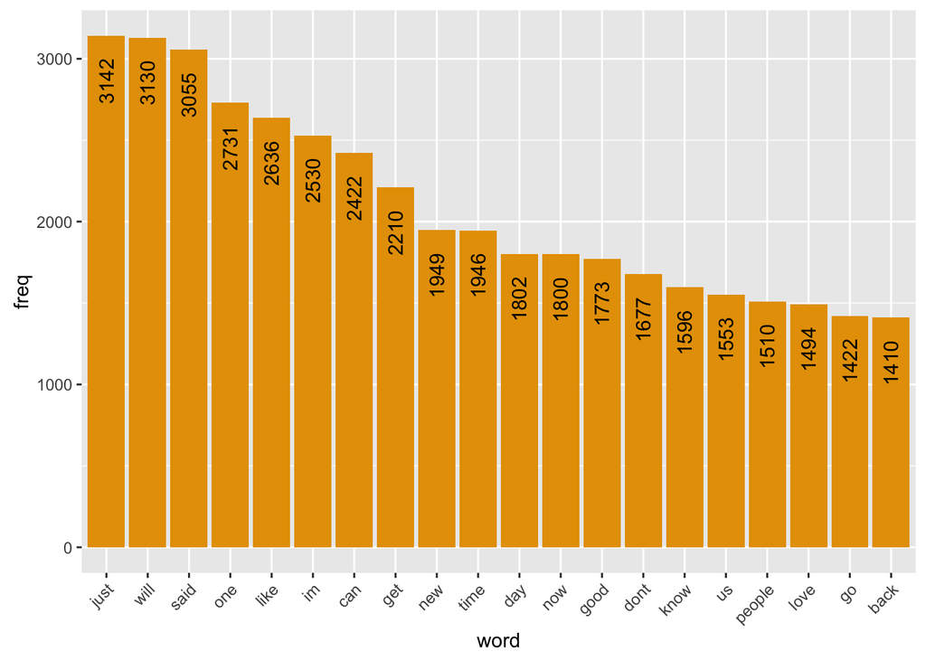

```r
# Prepare and plot bi-grams
unigram <- NGramTokenizer(docs, Weka_control(min = 1, max = 1,delimiters = " \\r\\n\\t.,;:\"()?!"))
unigram <- data.frame(table(unigram))
unigram <- unigram[order(unigram$Freq,decreasing = TRUE),]
colnames(unigram) <- c("word","freq")
unigram$word <- factor(unigram$word, levels = unigram$word)

ggplot(unigram[1:20,], aes(x=word,y=freq)) +
  geom_bar(stat="Identity", fill="#E69F00") +
  geom_text(aes(label=freq, angle=90), hjust=1.50) +
  theme(axis.text.x = element_text(angle = 45, hjust = 1))
```

- Exploring bi-gram distribution in the sample corpus

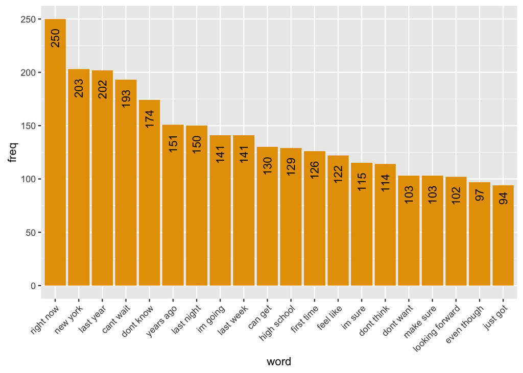

```r
# Prepare and plot bi-grams
bigram <- NGramTokenizer(docs, Weka_control(min = 2, max = 2,delimiters = " \\r\\n\\t.,;:\"()?!"))
bigram <- data.frame(table(bigram))
bigram <- bigram[order(bigram$Freq,decreasing = TRUE),]
colnames(bigram) <- c("word","freq")
bigram$word <- factor(bigram$word, levels = bigram$word)

ggplot(bigram[1:20,], aes(x=word,y=freq)) +
  geom_bar(stat="Identity", fill="#E69F00") +
  geom_text(aes(label=freq, angle=90), hjust=1.50) +
  theme(axis.text.x = element_text(angle = 45, hjust = 1))
```

- Exploring tri-gram distribution in the sample corpus

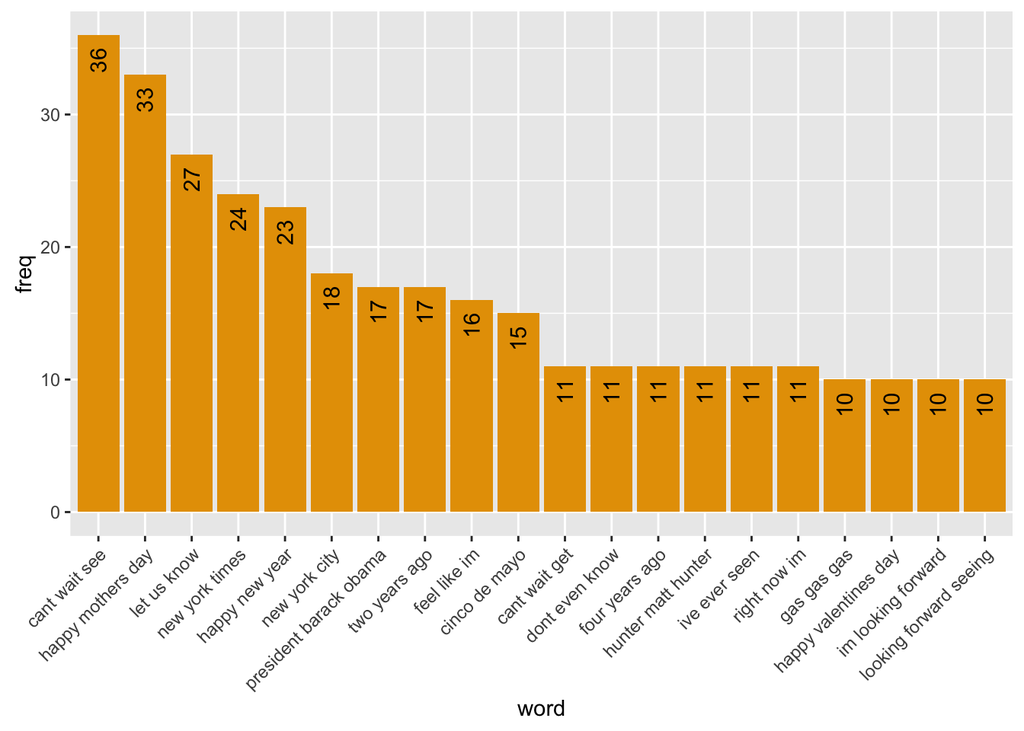

```r
# Prepare and plot tri-grams
trigram <- NGramTokenizer(docs, Weka_control(min = 3, max = 3,delimiters = " \\r\\n\\t.,;:\"()?!"))
trigram <- data.frame(table(trigram))
trigram <- trigram[order(trigram$Freq,decreasing = TRUE),]
colnames(trigram) <- c("word","freq")
trigram$word <- factor(trigram$word, levels = trigram$word)

ggplot(trigram[1:20,], aes(x=word,y=freq)) +
  geom_bar(stat="Identity", fill="#E69F00") +
  geom_text(aes(label=freq, angle=90), hjust=1.50) +
  theme(axis.text.x = element_text(angle = 45, hjust = 1))
```

## Interesting findings And Next Steps

The plot of bigram and trigram shows a good overlap i.e. the most frequent trigrams also have parts of it appear in most frequent bigrams. This seems to indicate that we could, in first pass, stick to bigram based prediction model. I plan to us Laplace smoothing with bigram to build the prediction model.

I will also build a shiny app which will have a test field and a button. Once you enter a phrase in the input field and click the button, it will guess the next best word to extend the input phase.